# Worksheet 99

## Making soap

A factory makes soap. There are two production lines, `a` and `b`. These can be run at different speeds; running the production line faster produces more soap, but it also produces more scrap (soap that cannot be sold). Does the amount of scrap differ by production line? Answer the questions below to find out. The data is in https://ritsokiguess.site/datafiles/soap.txt.

3. Read in and display some of the data.

```r
my_url <- "https://ritsokiguess.site/datafiles/soap.txt"
soap <- read_delim(my_url, " ")
soap
```

| case | scrap | speed | line |
| --- | --- | --- | --- |
| 1 | 218 | 100 | a |
| 2 | 248 | 125 | a |
| 3 | 360 | 220 | a |
| 4 | 351 | 205 | a |
| 5 | 470 | 300 | a |
| 6 | 394 | 255 | a |
| 7 | 332 | 225 | a |
| 8 | 321 | 175 | a |
| 9 | 410 | 270 | a |
| 10 | 260 | 170 | a |

[output cut: 17 more lines]

4. Make a suitable plot of the scrap produced and the production line. How do the production lines compare?

A boxplot:

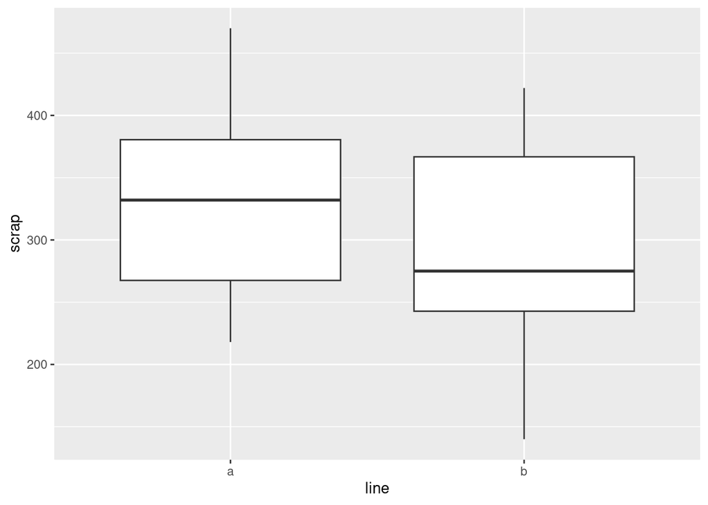

```r
ggplot(soap, aes(x = line, y = scrap)) + geom_boxplot()
```

Not much difference between the production lines relative to the amount of variability present.

5. Do you get a different story if you include speed in your plot?

A scatterplot this time:

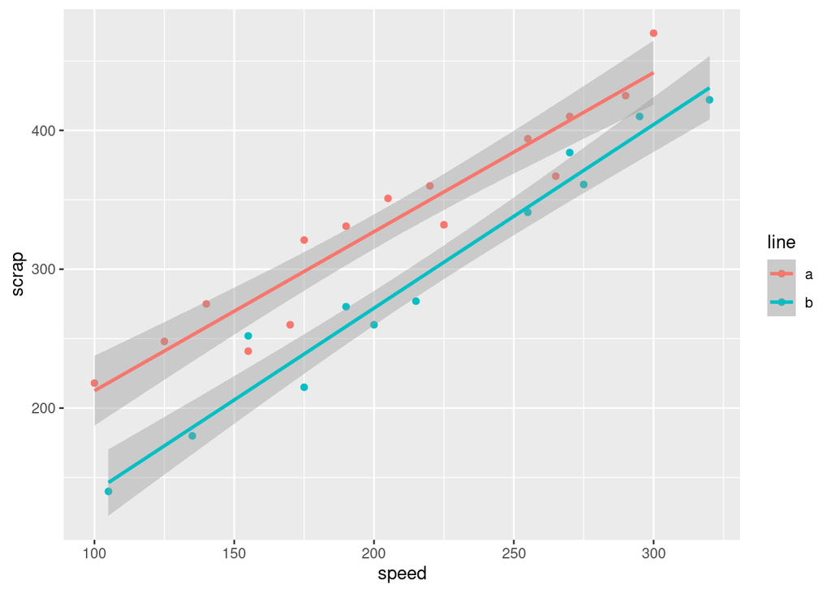

```r
ggplot(soap, aes(x = speed, y = scrap, colour = line)) +
  geom_point() + geom_smooth(method = "lm")
```

Once you allow for the speed at which the production line is run, line A produces more scrap than line B at any speed.